# Clocks and Rocks

Matheus Januario and Jennifer Auler

Dec/2023

```r
library(evolved)

# Let's also store our par() configs so
# we can restore them whenever we change it in this tutorial
oldpar <- par(no.readonly = TRUE)
```

rocks_and_clocks.R

## The fossil record:

Here we will use data on fossilized organism, which we call “fossil occurrences”. the data was originally obtained from the Paleobiology database, a free-to-use resource that is the standard repository for such data and which has been used by hundreds or thousands of scientific research articles to study the history and dynamics of biodiversity in Deep Time.

```r
data("dinos_fossil")
head(dinos_fossil)
```

```
##     phylum        class              order              family
## 1 Chordata Ornithischia NO_ORDER_SPECIFIED    Chaoyangsauridae
## 2 Chordata   Saurischia       Avetheropoda NO_FAMILY_SPECIFIED
## 3 Chordata   Saurischia       Avetheropoda NO_FAMILY_SPECIFIED
## 4 Chordata   Saurischia       Avetheropoda     Tyrannosauridae
## 5 Chordata   Saurischia       Avetheropoda     Tyrannosauridae
## 6 Chordata Ornithischia NO_ORDER_SPECIFIED        Ceratopsidae
##               genus                   species early_interval late_interval
## 1    Chaoyangsaurus     Chaoyangsaurus youngi Late Tithonian   Valanginian
## 2 Protarchaeopteryx Protarchaeopteryx robusta Late Barremian  Early Aptian
## 3       Caudipteryx          Caudipteryx zoui Late Barremian  Early Aptian
## 4       Gorgosaurus      Gorgosaurus libratus Late Campanian
## 5       Gorgosaurus      Gorgosaurus libratus Late Campanian
## 6      Centrosaurus      Centrosaurus apertus Late Campanian
##   max_ma min_ma midpoint       lng      lat
## 1  150.8 132.90   141.85  123.9667 42.93330
## 2  130.0 122.46   126.23  120.7333 41.80000
## 3  130.0 122.46   126.23  120.7333 41.80000
## 4   83.5  70.60    77.05 -111.5287 50.74073
## 5   83.5  70.60    77.05 -111.5493 50.73701
## 6   83.5  70.60    77.05 -111.5289 50.73730
```

rocks_and_clocks.R

Students can use functions in the package to calculate the diversity of a certain taxonomic rank, and plot it through time.

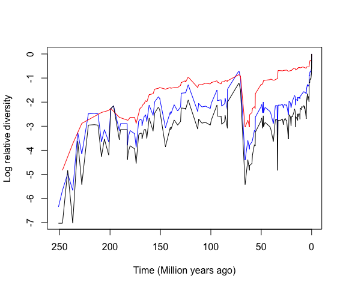

```r
spDTT = calcFossilDivTT(dinos_fossil, tax.lvl = "species")
genusDTT = calcFossilDivTT(dinos_fossil, tax.lvl = "genus")
famDTT = calcFossilDivTT(dinos_fossil, tax.lvl = "family")

# And to allow comparisons, we will use relative richness:
plot(x=genusDTT$age, xlim = rev(range(genusDTT$age)),
     y=log(genusDTT$div)-log(max(genusDTT$div)),
     xlab="Time (Million years ago)",
     ylab="Log relative diversity",
     type="l", col="blue", ylim=c(-7,0))

lines(x=famDTT$age,
     y=log(famDTT$div)-log(max(famDTT$div)),
     col="red")

lines(x=spDTT$age,
     y=log(spDTT$div)-log(max(spDTT$div)),
     col="black")
```

rocks_and_clocks.R

We can also visualize fossil records by running:

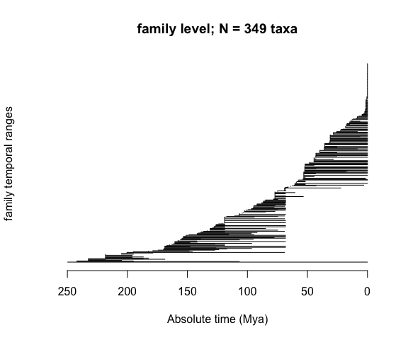

```r
# Family-level:
plotRawFossilOccs(dinos_fossil, tax.lvl = "family", knitr = TRUE)
```

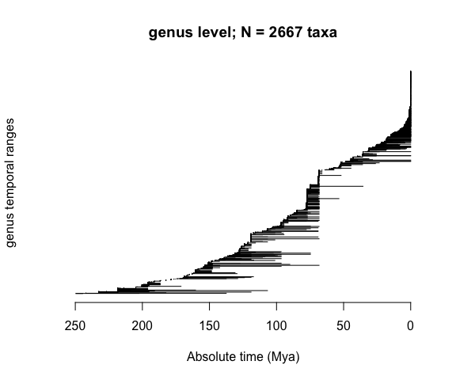

```r
# Genus level:
plotRawFossilOccs(dinos_fossil, tax.lvl = "genus", knitr = TRUE)
```

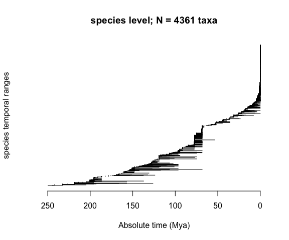

```r
# Species level:
plotRawFossilOccs(dinos_fossil, tax.lvl = "species", knitr = TRUE)
```

rocks_and_clocks.R

Are they different? how could we test? Hint: look at the column names of the fossil object:

```r
colnames(dinos_fossil)
```

```
##  [1] "phylum"         "class"          "order"          "family"
##  [5] "genus"          "species"        "early_interval" "late_interval"
##  [9] "max_ma"         "min_ma"         "midpoint"       "lng"
## [13] "lat"
```

rocks_and_clocks.R

Now, how complete is the record? We can use another dataset to explored this:

```r
data("birds_spp")
```

rocks_and_clocks.R

And see the proportion of living species with a fossil occurrence.

```r
sum_w_fossil = sum(birds_spp %in% dinos_fossil$species)

sum_w_fossil / length(birds_spp)
```

```
## [1] 0.1139798
```

rocks_and_clocks.R

Results from this dataset can also be compared (when relevant) with other fossil records, like those one can download from the Paleobiology Database.

We can also compare the temporal trends of species number, for instance. To help in that way, we also provide biodiversity timeseries for more clades:

```r
data("timeseries_fossil")
head(timeseries_fossil)
```

```
##   clade    source stem_age rel_time time_ma richness
## 1  anth Alroy2010      617  617.000   0.000     7138
## 2  anth Alroy2010      617  609.754   7.246     7246
## 3  anth Alroy2010      617  601.030  15.970    12673
## 4  anth Alroy2010      617  593.970  23.030     8485
## 5  anth Alroy2010      617  583.100  33.900    14475
## 6  anth Alroy2010      617  575.800  41.200     9280
```

rocks_and_clocks.R

It contains many fossil datasets, and we will only plot the first 4 of them

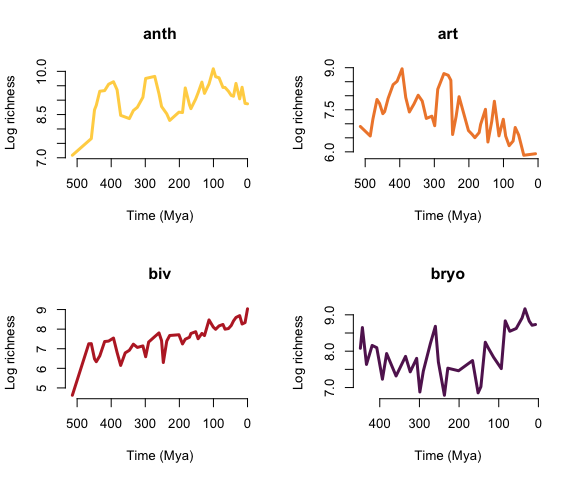

```r
clades = unique(timeseries_fossil$clade)[1:4]

cols= c("#ffd353", "#ef8737", "#bb292c", "#62205f")

par(mfrow=c(2,2))
for(i in 1:length(clades)){
  aux = timeseries_fossil[timeseries_fossil$clade==clades[i], ]
  plot(aux$time_ma, log(aux$richness), col=cols[i], lwd=3,
       main=clades[i], type="l", frame.plot = F,
       xlab="Time (Mya)", ylab="Log richness",
       xlim=rev(range(aux$time_ma)))
}
```

```r
# Restoring old par() configs:
par(oldpar)
```

rocks_and_clocks.R

Students can explore this other dataset, and compare it with the previously discussed ones. They can compare richness thought time, calculate statistics related to richness change. Explore factors (e.g. mass extinction) that might have affected some clades, among other learning problems.

But fossils are not the only way to explore the timescale of evolution. Below, we are going to show how some functions that use this type of data work.

## Comparing molecular patterns

With other functions, students can also explore molecular sequences and compare species.

First we load the dataset of protein sequences from the cytochrome oxidase 1 gene. This gene, often known as `CO1`, is a mitochondrial gene that plays a key role in cellular respiration (e.g., the primary aerobic pathway to energy ( ATP ) generation). `CO1` contains approximately 513 aminoacids (AA) and has been used by previous studies for reconstructing phylogenetic trees and estimating divergence times between taxa by assuming a molecular clock:

```r
data(cytOxidase)

summary(cytOxidase)
```

```
##
## 17 amino acid sequences, each with length 513
```

```r
head(cytOxidase)
```

```
## $cnidaria
## [1] "-RWIFSTNHKDIGTLYL"
##
## $snake
## [1] "TRWLFSTNHKDIGTLYL"
##
## $echinoderm
## [1] "NRWLFSTNHKDIGTLYL"
##
## $mollusk
## [1] "MRWLFSTNHKDIGTLYI"
##
## $alligator
## [1] "HRWFFSTNHKDIGTLYF"
##
## $lamprey
## [1] "IRWLFSTNHKDIGTLYL"
##
## $shark
## [1] "NRWLFSTNHKDIGTLYL"
##
## $bird
## [1] "NRWLFSTNHKDIGTLYL"
##
## $frog
## [1] "TRWLFSTNHKDIGTLYL"
##
## $fish
## [1] "TRWLFSTNHKDIGTLYL"
##
## $platypus
## [1] "NRWLFSTNHKDIGTLYL"
##
## $human
## [1] "DRWLFSTNHKDIGTLYL"
##
## $chimpanzee
## [1] "DRWLFSTNHKDIGTLYL"
##
## $bryozoa
## [1] "MRWLGSTNHKDIGTLYF"
##
## $annelid
## [1] "MRWLYSTNHKDIGTLYF"
##
## $insect
## [1] "RQWLFSTNHKDIGTLYF"
##
## $crustacea
## [1] "RQWLFSTNHKDIGTLYL"
```

rocks_and_clocks.R

We can compare two sequences in terms AA difference number. For instance if we want to compare a species of snake with one species of bird, we type:

```r
countSeqDiffs(cytOxidase, "snake", "bird")
```

```
## [1] 123
```

rocks_and_clocks.R

And to calculate the proportion of differences, we type:

```r
countSeqDiffs(cytOxidase, "snake", "bird")/nchar(cytOxidase["snake"])
```

```
##     snake
## 0.2397661
```

rocks_and_clocks.R

We can also quickly visualize the sequences by directly handling all elements in this object:

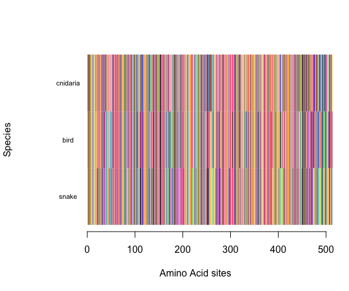

```r
plotProteinSeq(cytOxidase, c("snake", "bird", "cnidaria"), knitr = TRUE)
```

rocks_and_clocks.R

And using patterns of molecular divergence, as well as fossil occurrences, we can build and, specially, date, molecular phylogenies.